# p8105_hw1_ps3195

Pengyuan Su, UNI:ps3195

9/15/2020

#### **Solution to Homework 1:**

```r
library(tidyverse)
```

```r
library(ggplot2)
set.seed(1)
```

### *Problem 1*

Create a data frame comprised of required elements:

```r
prob1_df = tibble(
  samp = rnorm(10),
  samp_gt_0 = samp > 0,
  char_vec = c("a", "b", "c", "d", "e", "f", "g", "h", "i", "j"),
  factor_vec = factor(c("hard", "hard", "hard", "normal", "normal", "normal", "normal", "easy", "easy", "easy"))
)
```

Take the **mean** of each variable in the data frame:

```r
mean(pull(prob1_df, samp))
```

```
## [1] 0.1322028
```

```r
mean(pull(prob1_df, samp_gt_0))
```

```
## [1] 0.6
```

```r
mean(pull(prob1_df, char_vec))
```

```
## [1] NA
```

```r
mean(pull(prob1_df, factor_vec))
```

```
## [1] NA
```

The mean of **numbers and logical vector** works while the mean of **character and factor** does not make it.

Convert variables from one type to another:

```r
as.numeric(pull(prob1_df, samp_gt_0))
```

```
##  [1] 0 1 0 1 1 0 1 1 1 0
```

```r
as.numeric(pull(prob1_df, char_vec))
```

```
##  [1] NA NA NA NA NA NA NA NA NA NA
```

```r
as.numeric(pull(prob1_df, factor_vec))
```

```
##  [1] 2 2 2 3 3 3 3 1 1 1
```

The **logical vector and the factor vector** have been converted to numerical while the **character** failed since they are shown “NA”.

```r
as.numeric(pull(prob1_df, samp_gt_0)) * pull(prob1_df, samp)
```

```
##  [1] 0.0000000 0.1836433 0.0000000 1.5952808 0.3295078 0.0000000 0.4874291
##  [8] 0.7383247 0.5757814 0.0000000
```

```r
as.numeric(pull(prob1_df, factor_vec)) * pull(prob1_df, samp)
```

```
##  [1] -1.2529076  0.3672866 -1.6712572  4.7858424  0.9885233 -2.4614052
##  [7]  1.4622872  0.7383247  0.5757814 -0.3053884
```

```r
as.numeric(as.factor(pull(prob1_df, samp_gt_0))) * pull(prob1_df, samp)
```

```
##  [1] -0.6264538  0.3672866 -0.8356286  3.1905616  0.6590155 -0.8204684
##  [7]  0.9748581  1.4766494  1.1515627 -0.3053884
```

### *Problem 2*

Load the `penguins` dataset:

```r
 data("penguins", package = "palmerpenguins")
```

The short description of the `penguins` dataset:

The name of this dataset is `penguins`. And variables in it are bill_depth_mm, bill_length_mm, body_mass_g, flipper_length_mm, island, sex, species, year. There are three factors which are `species`, `island` and `sex`,five numeric vectors are `bill_length_mm`, `bill_depth_mm`,`flipper_length_mm`, `body_mass_g` and `year`.

Adelie, Chinstrap, Gentoo are the three levels of `species`, while Biscoe, Dream, Torgersen are the three levels of `island`. `sex` is divided into female, male.

The *range* of bill length is (32.1, 59.6) and the *mean* of it is 43.9219298.

The *range* of bill depth is (13.1, 21.5) and the *mean* of it is 17.1511696.

The *range* of flipper length is (172, 231). The *mean* of flipper length is 200.9152047.

The *year* is from 2007 to 2009.

The *size* of data is: 344 rows * 8 columns

> scatterplot

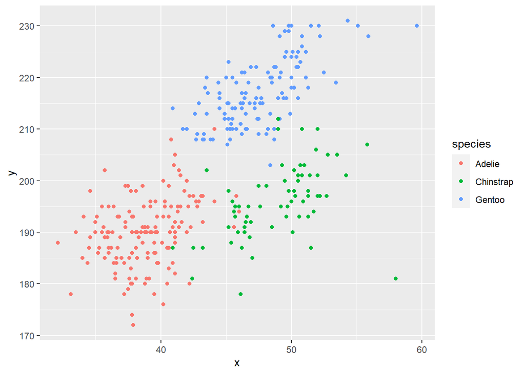

```r
plot_df = tibble(
  x = pull(penguins, bill_length_mm),
  y = pull(penguins, flipper_length_mm),
  species = pull(penguins, species)
)

ggplot(plot_df, aes(x = x, y = y, color = species)) + geom_point()
```

```r
ggsave("scatter_plot.pdf", height = 6, width = 6)
```